# 14.388 homework 8

# Study Problem 3

In this problem, we simulate a linear IV model and a linear model with proxies to demonstrate numerically that simple OLS provides inaccurate estimates while using instrumental variables can overcome the issue.

## Linear IV Model

Here we consider the following DAG, where $D$ causes $Y$, with the unobserved confounder $A$ and the instrumental variable $Z$.

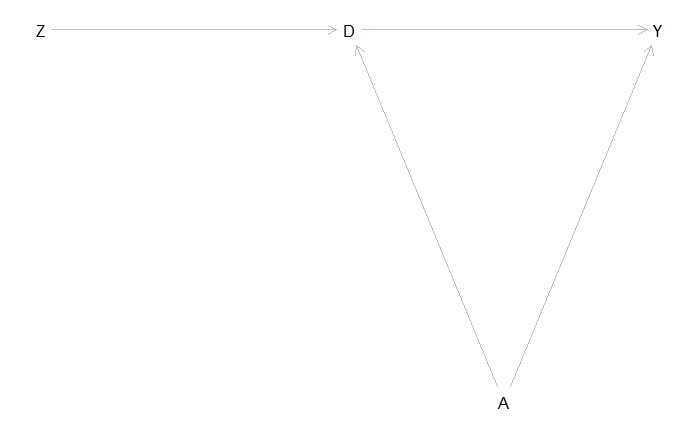

```r
library(tidyverse)
library(dagitty)
library(lfe)

dag.iv <- dagitty('dag {
  Z [pos = "0, 0"]
  D [pos = "1, 0"]
  Y [pos = "2, 0"]
  A [pos = "1.5, 0.5"]
  Z -> D
  D -> Y
  A -> D
  A -> Y
}')
plot(dag.iv)
```

In terms of the SEM, we can transform the DAG as follows:

$$\begin{align*}
Y &:= \alpha D + \delta A + \epsilon_Y \\
D &:= \beta Z + \gamma A + \epsilon_D \\
A &:= \epsilon_A \\
Z &:= \epsilon_Z
\end{align*}$$

Based on the SEM, let’s simulate with artificially generated data and compare the estimates of simple OLS and IV regression.

```r
set.seed(1)
n <- 1000
tb.iv <- tibble(
  z = rnorm(n),
  a = rnorm(n),
  d = z + a + rnorm(n),
  y = d + a + rnorm(n)
)
lm.ols.iv <- tb.iv %>% lm(y ~ d, .)
summary(lm.ols.iv)
```

```
Call:
lm(formula = y ~ d, data = .)

Residuals:
    Min      1Q  Median      3Q     Max
-4.2324 -0.9539 -0.0432  0.9288  4.1058

Coefficients:
            Estimate Std. Error t value Pr(>|t|)
(Intercept) 0.004803   0.042355   0.113     0.91
d           1.344654   0.023038  58.367   <2e-16 ***
---
Signif. codes:  0 ‘***’ 0.001 ‘**’ 0.01 ‘*’ 0.05 ‘.’ 0.1 ‘ ’ 1

Residual standard error: 1.339 on 998 degrees of freedom
Multiple R-squared:  0.7734,    Adjusted R-squared:  0.7732
F-statistic:  3407 on 1 and 998 DF,  p-value: < 2.2e-16
```

According to the simulation, the true value of $\alpha$ is 1. However, the simple OLS regression of $Y$ on $D$ generated a much higher estimate of $\alpha$ because it could not account for the unobserved confounder $A$.

```r
lm.iv <- tb.iv %>% felm(y ~ 1 | 0 | (d ~ z), .)
summary(lm.iv)
```

```
Call:
   felm(formula = y ~ 1 | 0 | (d ~ z), data = .)

Residuals:
    Min      1Q  Median      3Q     Max
-5.0241 -0.9732  0.0041  1.0096  4.7849

Coefficients:
             Estimate Std. Error t value Pr(>|t|)
(Intercept) 0.0008183  0.0461825   0.018    0.986
`d(fit)`    1.0284087  0.0422914  24.317   <2e-16 ***
---
Signif. codes:  0 ‘***’ 0.001 ‘**’ 0.01 ‘*’ 0.05 ‘.’ 0.1 ‘ ’ 1

Residual standard error: 1.46 on 998 degrees of freedom
Multiple R-squared(full model): 0.7306   Adjusted R-squared: 0.7304
Multiple R-squared(proj model): 0.7306   Adjusted R-squared:
```

[output not shown]

```
0.7304
F-statistic(full model):591.3 on 1 and 998 DF, p-value: < 2.2e-16
F-statistic(proj model): 591.3 on 1 and 998 DF, p-value: < 2.2e-16
F-statistic(endog. vars):591.3 on 1 and 998 DF, p-value: < 2.2e-16
```

On the other hand, the IV regression using the instrument $Z$ provides an accurate estimate of $\alpha$ as it takes advantage of the exogenous variation of $D$ brought about by $Z$.

## Linear Model with Proxy Controls

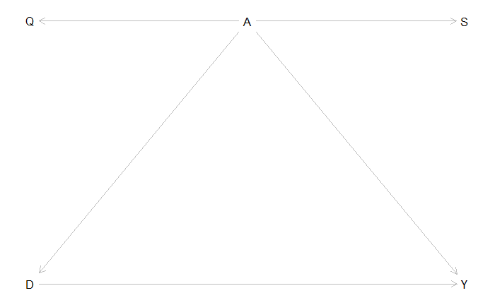

```r
dag.proxy <- dagitty('dag {
  Q [pos = "0, 0"]
  A [pos = "1, 0"]
  S [pos = "2, 0"]
  D [pos = "0, 1"]
  Y [pos = "2, 1"]
  A -> Q
  A -> D
  A -> Y
  A -> S
  D -> Y
}')
plot(dag.proxy)
```

In terms of the SEM, we can transform the DAG as follows:

$$\begin{align*}
Y &:= \alpha D + \beta A + \epsilon_Y \\
D &:= \gamma A + \epsilon_D \\
Q &:= \delta A + \epsilon_Q \\
S &:= \eta A + \epsilon_S \\
A &:= \epsilon_A
\end{align*}$$

Based on the SEM, let’s simulate with artificially generated data and compare the estimates of simple OLS and IV regression.

```r
set.seed(2)
n <- 1000
tb.proxy <- tibble(
  a = rnorm(n),
  s = a + rnorm(n),
  q = a + rnorm(n),
  d = a + rnorm(n),
  y = d + a + rnorm(n)
)
lm.ols.proxy <- tb.proxy %>% lm(y ~ d, .)
summary(lm.ols.proxy)
```

```
Call:
lm(formula = y ~ d, data = .)

Residuals:
    Min      1Q  Median      3Q     Max
-4.6135 -0.7979  0.0346  0.8187  3.8811

Coefficients:
            Estimate Std. Error t value Pr(>|t|)
(Intercept)  0.03848    0.03900   0.987    0.324
d            1.56258    0.02838  55.055   <2e-16 ***
---
Signif. codes:  0 ‘***’ 0.001 ‘**’ 0.01 ‘*’ 0.05 ‘.’ 0.1 ‘ ’ 1

Residual standard error: 1.231 on 998 degrees of freedom
Multiple R-squared:  0.7523,    Adjusted R-squared:  0.7521
F-statistic:  3031 on 1 and 998 DF,  p-value: < 2.2e-16
```

The true value of $\alpha$ is 1 in the simulation. However, the estimate of $\alpha$ from the simple OLS regression of $Y$ on $D$ is much higher because the unobserved confounder $A$ was missing from the regression.

```r
lm.proxy <- tb.proxy %>% felm(y ~ d | 0 | (q ~ s), .)
summary(lm.proxy)
```

```
Call:
   felm(formula = y ~ d | 0 | (q ~ s), data = .)

Residuals:
    Min      1Q  Median      3Q     Max
-4.0724 -0.9742 -0.0287  0.9547  6.5710

Coefficients:
            Estimate Std. Error t value Pr(>|t|)
(Intercept) -0.04608    0.04577  -1.007    0.314
d            1.01090    0.06753  14.969   <2e-16 ***
`q(fit)`     1.02857    0.11021   9.332   <2e-16 ***
---
Signif. codes:  0 ‘***’ 0.001 ‘**’ 0.01 ‘*’ 0.05 ‘.’ 0.1 ‘ ’ 1

Residual standard error: 1.416 on 997 degrees of freedom
Multiple R-squared(full model): 0.6725   Adjusted R-squared: 0.6718
Multiple R-squared(proj model): 0.6725   Adjusted R-squared: 0.6718
F-statistic(full model): 1189 on 2 and 997 DF, p-value: < 2.2e-16
F-statistic(proj model):  1189 on 2 and 997 DF, p-value: < 2.2e-16
F-statistic(endog. vars): 87.1 on 1 and 997 DF, p-value: < 2.2e-16
```

In contrast, the IV regression provides an accurate estimate of $\alpha$ as it used the proxy $Q$ to control for the unobserved confounder $A$ and instrumented $Q$ with the other proxy $S$ to account for measurement errors.